# Calcium Flex Analysis using Python

*Author Lawrence Collins*

Jupyter Notebok allows narrative text and live code to be held in separate cells.  
The below functions utilise *Object Orientated Programming* to hide the majority of the code 'under the bonnet'

# Single plate processing

## Importing the package

- to add the software's functionality to the notebook, the below command is used
- calcium_flex contains all the functions required for the processing and analysis of a single well plate experiment

```python
from calciumflexanalysis import calcium_flex as cal
```

## Uploading Flex data

```python
# text file to be read in (raw file from machine)
datafile = 'data_example 3 nM to 3 uM.txt'

# plate map csv file updated by user (either the 'short' or 'long' template)
mapcsv = 'plate-map_example 3nM to 3 uM.csv'

# insert the 2 files into the 'CaFlexAnalysis' class
# it is recommended the user name the plates via the system 'plate1', 'plate2', etc.
plate1 = cal.CaFlexPlate(raw_data = datafile, plate_map_file = mapcsv, inject = 60, data_type = 'new')
```

```
Uploaded!
```

## Visual inspection

Two functions assist the user in checking the arrangment of the well plate and for any anomalous readings.

### see_plate()

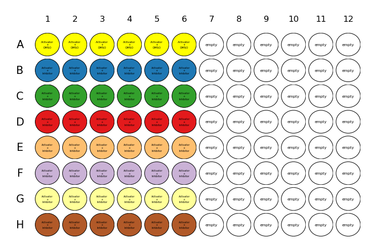

```python
plate1.see_plate(colorby = 'Concentration', labelby = 'Contents')
```

### visualise_assay()

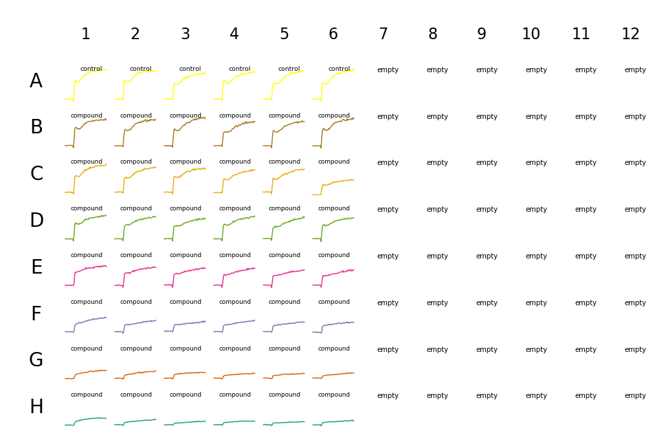

```python
plate1.visualise_assay(share_y = True, colorby = 'Concentration')
```

## Invalidation

Visualising the assay allows the user to note any anomalous recordings. The user can then choose to have a closer look at the dodgy data and invalidate if necessary.

### see_wells()

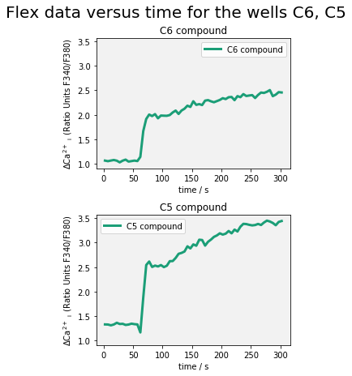

```python
# specific wells that look dodgy
plate1.see_wells(["C6", "C5"])
```

The user can invalidate individual wells or entire rows and columns.

```python
plate1.invalidate_wells(["C6"])

plate1.invalidate_rows('B')

plate1.invalidate_cols(5)
```

```
['C6'] invalidated
Row B invalidated
Columns 5 invalidated
```

Visualising the assays will clearly show which wells are now invalidated.

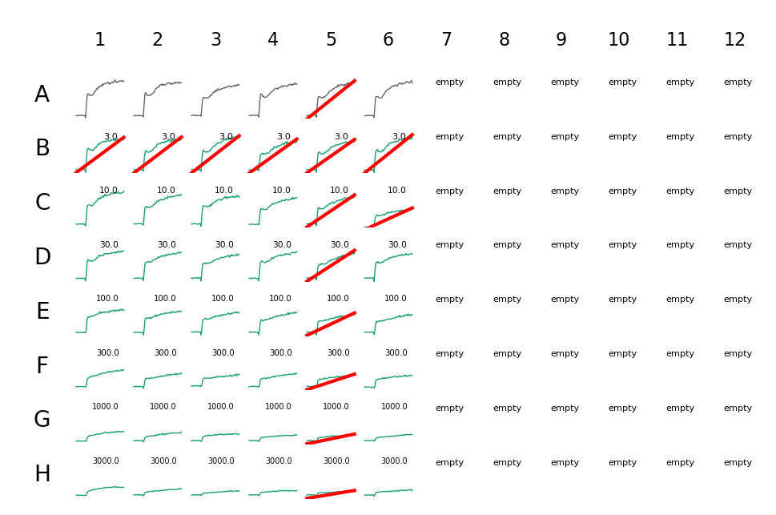

```python
plate1.visualise_assay(labelby = 'Concentration', share_y = True)
```

## Data Analysis

### Baseline Correction: baseline_correct()

```python
plate1.baseline_correct()
```

```
Baseline corrected! See self.processed_data['baseline_corrected']
```

### get_window()

```python
plate1.get_window('baseline_corrected')
```

### plot_conditions()

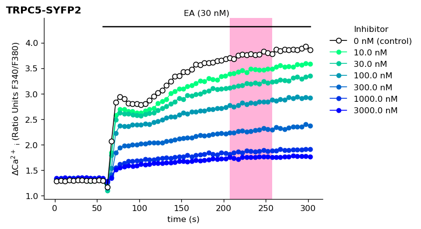

```python
plate1.plot_conditions('ratio', activator = "EA (30 nM)", title = 'TRPC5-SYFP2', show_window = True)
```

```python
# # uncomment to manually set the window
plate1.def_window(250, 'baseline_corrected')
plate1.window # .window returns the index from which the window will be taken
```

```
(50, 60)
```

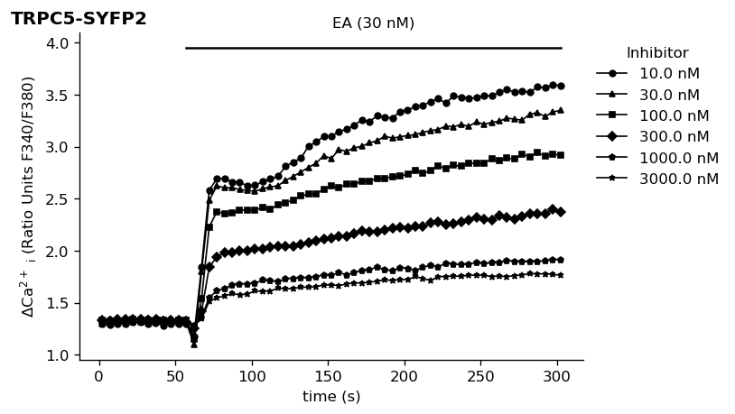

```python
plate1.plot_conditions('ratio', activator = "EA (30 nM)", title = 'TRPC5-SYFP2', show_window = False,
                       unique_markers = True, show_control = False)
# typically plot 'ratio' to avoid obfuscating any pre-injection data
```

### Amplitudes

```python
plate1.amplitude('baseline_corrected')
```

```
Amplitudes calculated from baseline_corrected. See self.processed_data['plateau']['data']
```

### Normalisation

```python
plate1.normalise()
```

|  | amps_normed |
| --- | --- |
| A1 | 105.954994 |
| A2 | 101.923136 |
| A3 | 91.997677 |
| A4 | 96.487199 |
| A5 | 99.968959 |
| ... | ... |
| H8 | NaN |
| H9 | NaN |
| H10 | NaN |
| H11 | NaN |
| H12 | NaN |

96 rows × 1 columns

### mean_amplitude()

```python
plate1.mean_amplitude(use_normalised = True)
```

|  | Protein | Type | Compound | Concentration | Concentration Units | amps_normed | amps_normed_error |
| --- | --- | --- | --- | --- | --- | --- | --- |
| 0 | -1 | empty | -1 | -1.0 | -1 | NaN | NaN |
| 1 | TRPC5 | compound | Inhibitor | 10.0 | nM | 87.374056 | 3.624560 |
| 2 | TRPC5 | compound | Inhibitor | 30.0 | nM | 76.742719 | 2.054148 |
| 3 | TRPC5 | compound | Inhibitor | 100.0 | nM | 61.278236 | 2.742262 |
| 4 | TRPC5 | compound | Inhibitor | 300.0 | nM | 39.142850 | 2.845619 |
| 5 | TRPC5 | compound | Inhibitor | 1000.0 | nM | 21.716848 | 2.299812 |
| 6 | TRPC5 | compound | Inhibitor | 3000.0 | nM | 16.496358 | 2.315117 |
| 7 | TRPC5 | control | -1 | -1.0 | nM | 100.000000 | 2.537372 |

### Curve fitting: plot_curve()

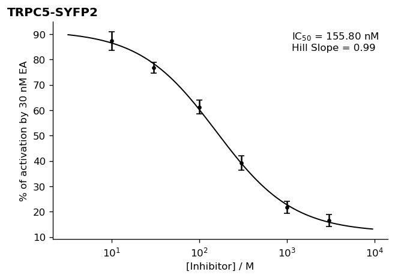

```python
plate1.plot_curve('ic50', activator = '30 nM EA', title = "TRPC5-SYFP2", use_normalised = True)
```

### export_data()

```python
# plate1.export_data("test_export.xlsx")
```

# Multi-plate processing

It is also possible to group together several assays for a combined analysis. This uses the 'multiplate' subpackage.

## Importing the package

```python
from calciumflexanalysis import multiplate as mp
```

## Uploading the flex data

```python
# text files to be read in
datafile = 'data_example 3 nM to 3 uM.txt'
datafile2 = 'data_example_multiple_compounds.txt'

mapcsv = 'plate-map_example 3nM to 3 uM.csv'
mapcsv2 = 'plate-map_example_multiple_compounds.csv'

# insert the 2 files into the 'CaFlexAnalysis' class
plate1 = cal.CaFlexPlate(raw_data = datafile, plate_map_file = mapcsv, inject = 60, data_type = 'new')
plate2 = cal.CaFlexPlate(raw_data = datafile2, plate_map_file = mapcsv2, inject = 60, data_type = 'old')
```

```
Uploaded!
Uploaded!
```

```python
# upload to CaFlexGroup
plates = mp.CaFlexGroup([plate1, plate2])
```

## Visual Inspection

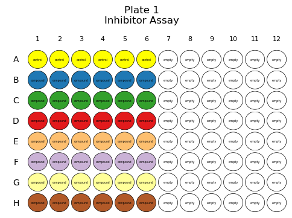

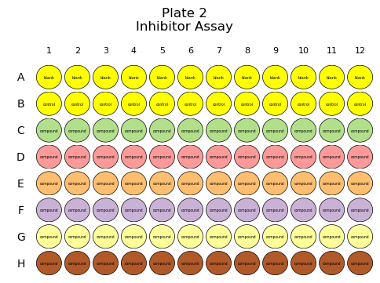

```python
plates.see_plates(title = 'Inhibitor Assay', colorby = 'Concentration')
```

## Data analysis of multiple plates

```python
plates.baseline_correct()
```

```
Baseline corrected! See self.processed_data['baseline_corrected']
Plate 1
Baseline corrected! See self.processed_data['baseline_corrected']
Plate 2
```

```python
plates.get_window('baseline_corrected')
```

```
(46, 56)
```

```python
plates.def_window(210, 'baseline_corrected')
```

```
all windows equal, self.window updated
```

```
(42, 52)
```

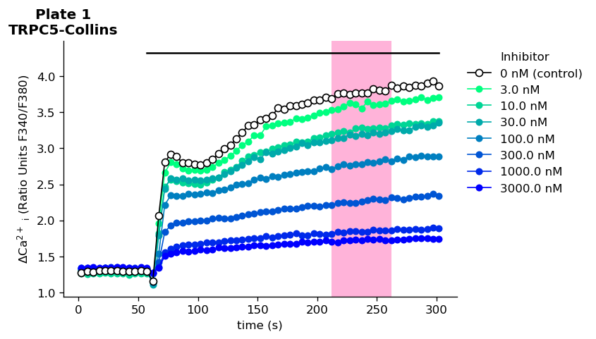

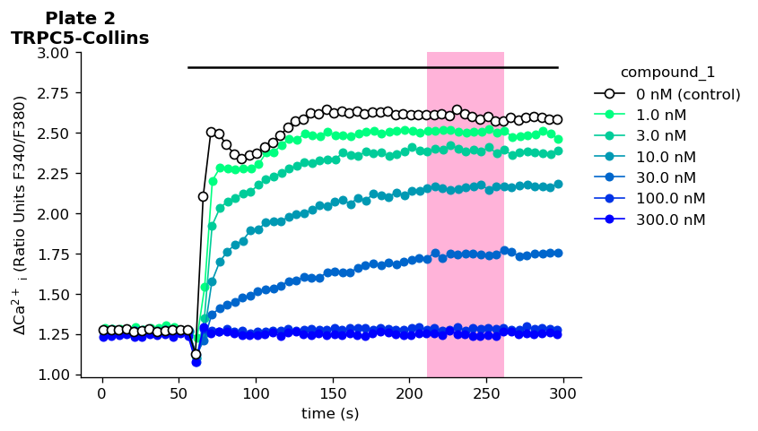

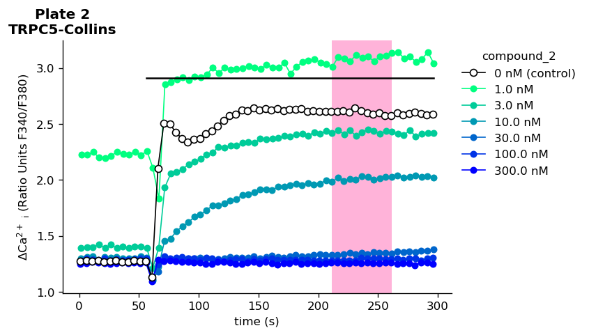

```python
plates.plot_conditions('ratio', show_window = True, title = "TRPC5-Collins", error = False)
```

```python
plates.amplitude('baseline_corrected')
```

```
Amplitudes calculated from baseline_corrected. See self.processed_data['plateau']['data']
self.processed_data['plateau']['data'] updated for plate 1.
Amplitudes calculated from baseline_corrected. See self.processed_data['plateau']['data']
self.processed_data['plateau']['data'] updated for plate 2.
self.data updated. See self.data[baseline_corrected]['grouped']
```

|  | Well ID | Type | Contents | Compound | Protein | Concentration | Concentration Units | Row | Column | Valid | Amplitude |
| --- | --- | --- | --- | --- | --- | --- | --- | --- | --- | --- | --- |
| 0 | A1 | control | Activator + DMSO | none | TRPC5 | none | nM | A | 1 | True | 2.521769 |
| 1 | A2 | control | Activator + DMSO | none | TRPC5 | none | nM | A | 2 | True | 2.445457 |
| 2 | A3 | control | Activator + DMSO | none | TRPC5 | none | nM | A | 3 | True | 2.094952 |
| 3 | A4 | control | Activator + DMSO | none | TRPC5 | none | nM | A | 4 | True | 2.186409 |
| 4 | A5 | control | Activator + DMSO | none | TRPC5 | none | nM | A | 5 | True | 2.236160 |
| ... | ... | ... | ... | ... | ... | ... | ... | ... | ... | ... | ... |
| 187 | H8 | compound | EA(30 nM) +IBP23 (1 nM) | compound_2 | TRPC5 | 1 | nM | H | 8 | True | 1.028408 |
| 188 | H9 | compound | EA(30 nM) +IBP23 (1 nM) | compound_2 | TRPC5 | 1 | nM | H | 9 | True | 0.580241 |
| 189 | H10 | compound | EA(30 nM) +IBP23 (1 nM) | compound_2 | TRPC5 | 1 | nM | H | 10 | True | 0.647634 |
| 190 | H11 | compound | EA(30 nM) +IBP23 (1 nM) | compound_2 | TRPC5 | 1 | nM | H | 11 | True | 1.120601 |
| 191 | H12 | compound | EA(30 nM) +IBP23 (1 nM) | compound_2 | TRPC5 | 1 | nM | H | 12 | True | 0.970461 |

192 rows × 11 columns

```python
plates.mean_amplitude()
```

|  | Protein | Type | Compound | Concentration | Concentration Units | Amplitude | Amplitude Error |
| --- | --- | --- | --- | --- | --- | --- | --- |
| 0 | TRPC5 | compound | Inhibitor | 3 | nM | 2.109437 | 0.063790 |
| 1 | TRPC5 | compound | Inhibitor | 10 | nM | 1.818791 | 0.139581 |
| 2 | TRPC5 | compound | Inhibitor | 30 | nM | 1.711808 | 0.055430 |
| 3 | TRPC5 | compound | Inhibitor | 100 | nM | 1.333943 | 0.075432 |
| 4 | TRPC5 | compound | Inhibitor | 300 | nM | 0.840459 | 0.054235 |
| 5 | TRPC5 | compound | Inhibitor | 1000 | nM | 0.455551 | 0.047928 |
| 6 | TRPC5 | compound | Inhibitor | 3000 | nM | 0.342732 | 0.055724 |
| 7 | TRPC5 | compound | compound_1 | 1 | nM | 1.216861 | 0.034730 |
| 8 | TRPC5 | compound | compound_1 | 3 | nM | 1.109066 | 0.031909 |
| 9 | TRPC5 | compound | compound_1 | 10 | nM | 0.841987 | 0.030580 |
| 10 | TRPC5 | compound | compound_1 | 30 | nM | 0.420972 | 0.029127 |
| 11 | TRPC5 | compound | compound_1 | 100 | nM | 0.017994 | 0.004049 |
| 12 | TRPC5 | compound | compound_1 | 300 | nM | 0.008708 | 0.006856 |
| 13 | TRPC5 | compound | compound_2 | 1 | nM | 0.801967 | 0.110768 |
| 14 | TRPC5 | compound | compound_2 | 3 | nM | 0.999166 | 0.058639 |
| 15 | TRPC5 | compound | compound_2 | 10 | nM | 0.649391 | 0.099005 |
| 16 | TRPC5 | compound | compound_2 | 30 | nM | 0.033789 | 0.022595 |
| 17 | TRPC5 | compound | compound_2 | 100 | nM | -0.002239 | 0.004872 |
| 18 | TRPC5 | compound | compound_2 | 300 | nM | -0.002768 | 0.004437 |
| 19 | TRPC5 | control | EA | none | nM | 1.347638 | 0.016135 |
| 20 | TRPC5 | control | none | none | nM | 2.303757 | 0.066007 |
| 21 | none | blank | none | none | none | 0.258315 | 0.262201 |
| 22 | none | empty | none | none | none | NaN | NaN |

```python
plates.normalise(combine = True)
```

```
Collated data normalised to mean control. See self.data['plateau']['data_normed']
```

|  | Well ID | Type | Contents | Compound | Protein | Concentration | Concentration Units | Row | Column | Valid | amps_normed |
| --- | --- | --- | --- | --- | --- | --- | --- | --- | --- | --- | --- |
| 0 | A1 | control | Activator + DMSO | none | TRPC5 | none | nM | A | 1 | True | 138.126335 |
| 1 | A2 | control | Activator + DMSO | none | TRPC5 | none | nM | A | 2 | True | 133.946448 |
| 2 | A3 | control | Activator + DMSO | none | TRPC5 | none | nM | A | 3 | True | 114.748055 |
| 3 | A4 | control | Activator + DMSO | none | TRPC5 | none | nM | A | 4 | True | 119.757442 |
| 4 | A5 | control | Activator + DMSO | none | TRPC5 | none | nM | A | 5 | True | 122.482485 |
| ... | ... | ... | ... | ... | ... | ... | ... | ... | ... | ... | ... |
| 187 | H8 | compound | EA(30 nM) +IBP23 (1 nM) | compound_2 | TRPC5 | 1 | nM | H | 8 | True | 56.329606 |
| 188 | H9 | compound | EA(30 nM) +IBP23 (1 nM) | compound_2 | TRPC5 | 1 | nM | H | 9 | True | 31.781896 |
| 189 | H10 | compound | EA(30 nM) +IBP23 (1 nM) | compound_2 | TRPC5 | 1 | nM | H | 10 | True | 35.473218 |
| 190 | H11 | compound | EA(30 nM) +IBP23 (1 nM) | compound_2 | TRPC5 | 1 | nM | H | 11 | True | 61.379364 |
| 191 | H12 | compound | EA(30 nM) +IBP23 (1 nM) | compound_2 | TRPC5 | 1 | nM | H | 12 | True | 53.155638 |

192 rows × 11 columns

```python
plates.mean_amplitude(use_normalised = True, combine = True)
```

|  | Protein | Type | Compound | Concentration | Concentration Units | amps_normed | amps_normed_error |
| --- | --- | --- | --- | --- | --- | --- | --- |
| 0 | TRPC5 | compound | Inhibitor | 3 | nM | 115.541437 | 3.494005 |
| 1 | TRPC5 | compound | Inhibitor | 10 | nM | 99.621698 | 7.645373 |
| 2 | TRPC5 | compound | Inhibitor | 30 | nM | 93.761871 | 3.036127 |
| 3 | TRPC5 | compound | Inhibitor | 100 | nM | 73.064830 | 4.131692 |
| 4 | TRPC5 | compound | Inhibitor | 300 | nM | 46.034934 | 2.970633 |
| 5 | TRPC5 | compound | Inhibitor | 1000 | nM | 24.952178 | 2.625176 |
| 6 | TRPC5 | compound | Inhibitor | 3000 | nM | 18.772650 | 3.052182 |
| 7 | TRPC5 | compound | compound_1 | 1 | nM | 66.651816 | 1.902298 |
| 8 | TRPC5 | compound | compound_1 | 3 | nM | 60.747528 | 1.747778 |
| 9 | TRPC5 | compound | compound_1 | 10 | nM | 46.118625 | 1.674962 |
| 10 | TRPC5 | compound | compound_1 | 30 | nM | 23.058128 | 1.595372 |
| 11 | TRPC5 | compound | compound_1 | 100 | nM | 0.985592 | 0.221754 |
| 12 | TRPC5 | compound | compound_1 | 300 | nM | 0.476980 | 0.375524 |
| 13 | TRPC5 | compound | compound_2 | 1 | nM | 43.926637 | 6.067160 |
| 14 | TRPC5 | compound | compound_2 | 3 | nM | 54.727894 | 3.211893 |
| 15 | TRPC5 | compound | compound_2 | 10 | nM | 35.569461 | 5.422870 |
| 16 | TRPC5 | compound | compound_2 | 30 | nM | 1.850761 | 1.237633 |
| 17 | TRPC5 | compound | compound_2 | 100 | nM | -0.122658 | 0.266847 |
| 18 | TRPC5 | compound | compound_2 | 300 | nM | -0.151627 | 0.243031 |
| 19 | TRPC5 | control | EA | none | nM | 73.814947 | 0.883783 |
| 20 | TRPC5 | control | none | none | nM | 126.185053 | 3.615420 |
| 21 | none | blank | none | none | none | 14.148864 | 14.361712 |
| 22 | none | empty | none | none | none | NaN | NaN |

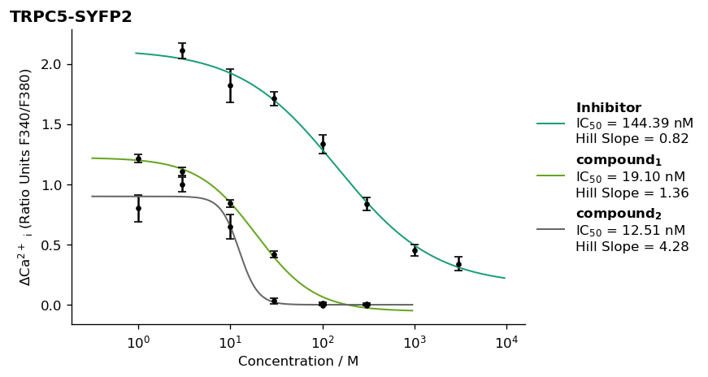

```python
plates.plot_curve('ic50', combine_plates = True, combine = True, use_normalised = False, activator = 'EA 30 nM', title = 'TRPC5-SYFP2')
```

```python
# plates.export_data(combine_plates = True)
```

# Activator Assays

EC50's can be straightforwardly plotted.

```python
data = 'activator_example_data.txt'
plate_map = 'activator_example_map.csv'
plate3 = cal.CaFlexPlate(raw_data = data, plate_map_file = plate_map, inject = 60, data_type = 'old')
```

```
Uploaded!
```

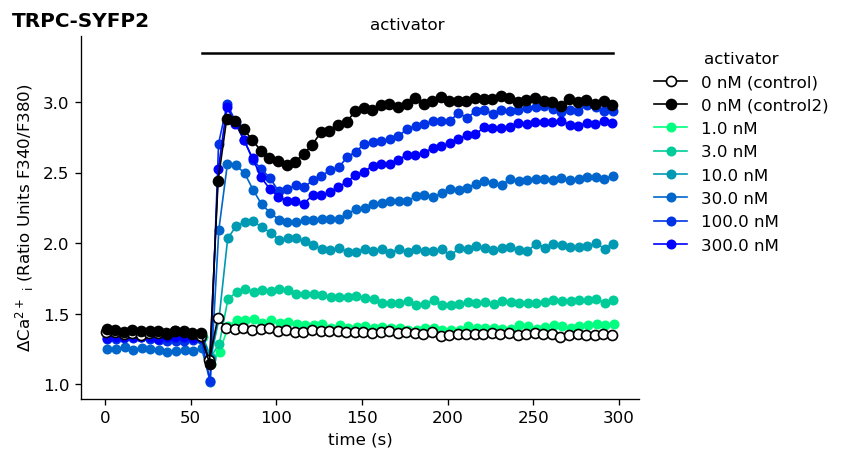

```python
plate3.plot_conditions('ratio', activator = "activator", title = "TRPC-SYFP2", control = ['control', 'control2'])
```

```python
plate3.baseline_correct()
```

```
Baseline corrected! See self.processed_data['baseline_corrected']
```

```python
plate3.get_window('baseline_corrected')
```

```python
plate3.amplitude('baseline_corrected')
```

```
Amplitudes calculated from baseline_corrected. See self.processed_data['plateau']['data']
```

```python
plate3.mean_amplitude()
```

|  | Protein | Type | Compound | Concentration | Concentration Units | Amplitude | Amplitude Error |
| --- | --- | --- | --- | --- | --- | --- | --- |
| 0 | -1 | empty | -1 | -1.0 | -1 | NaN | NaN |
| 1 | TRPC5-SYFP2 | compound | activator | 1.0 | nM | 0.056646 | 0.026389 |
| 2 | TRPC5-SYFP2 | compound | activator | 3.0 | nM | 0.232241 | 0.083927 |
| 3 | TRPC5-SYFP2 | compound | activator | 10.0 | nM | 0.625596 | 0.150927 |
| 4 | TRPC5-SYFP2 | compound | activator | 30.0 | nM | 1.207932 | 0.180265 |
| 5 | TRPC5-SYFP2 | compound | activator | 100.0 | nM | 1.633562 | 0.102630 |
| 6 | TRPC5-SYFP2 | compound | activator | 300.0 | nM | 1.517087 | 0.079105 |
| 7 | TRPC5-SYFP2 | control | -1 | 0.0 | nM | -0.010598 | 0.033528 |
| 8 | TRPC5-SYFP2 | control2 | EA | 10.0 | nM | 1.633284 | 0.107221 |

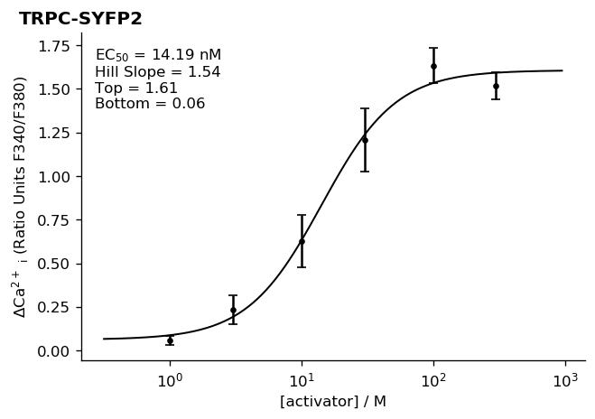

```python
plate3.plot_curve('ec50', title = 'TRPC-SYFP2', show_top_bot = True)
```